# Covariance Proof

Ali Taşbaş

2024-03-28

## Covariance of independent variables is 0

I was asked to prove the above statement. As I’m more into the new tools the world has to offer, I decided to get help from R. Instead of directly proving it, I will prove that the contrary is not possible by constructing a hypothesis test. I hope you will find my first R markdown project entertaining Hocam.

```r
covs <- c() # empty vector to store the sample covariances
plots <- data.frame(x = c(), y = c(), sample_no = c()) # empty list to store the scatter plots

for (i in 1:500) {

  x <- rnorm(75, 15, 8) # mean is 15, sd is 8

  y <- runif(75, 100, 150) # uniform between 100 and 150

  covs <- c(covs, cov(x, y))
  plots <- rbind(plots, data.frame(x = x, y = y, sample_no = i))
}
```

## A Scatter Plot

Here are 4 examples of the 500 scatter plots representing the combinations of x and y.

[figure not shown]

## Distribution of Covariances

Let’s check the distribution of the covariances of the samples

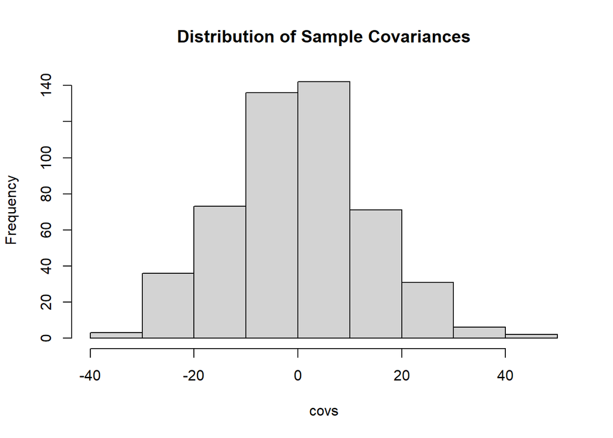

## Hypothesis Test

Now the fun part… We construct our null and alternative hypotheses.

**H<sub>0</sub>: COV(X,Y)=0**  
**H<sub>A</sub>: COV(X,Y)≠0**

$\bar{x}$<sub>cov</sub>=0.1533444
**S<sub>e</sub>**=1.9206048
$$\frac{{\bar{x} - \mu}}{{\sigma / \sqrt{n}}}$$

## Conclusion

We cannot claim that the covariance of 2 independent variables is different from 0 as our p-value is quite big.